# Week 5 Lab

Beatrix Jones

4/7/2020

In this lab we will go through the code used to produce the results for the EPL data. We use the canonical correlation function from a package called “vegan”, and the pls/plsda functions from a library called “mdatools.” If necessary you can install these with the command install.packages, for instance install.packages(“vegan”).

This first block of code loads the libraries and reads in the EPL data, removes the weird point with 657 shots on goal, and separates the home and away measures.

```r
library(vegan)
library(mdatools)
read.csv("EPLDataset.csv")->EPL
EPL<-EPL[-1112,]
home<-EPL[,c(3,7,9,11,13,15,17,19,21,27)]
away<-EPL[,c(seq(4,22,2),28)]
```

We run the analysis with the function called CCorA. It is worth naming the inputs with X= and Y= as all the output is labeled in terms of X and Y. We use the argument “permutations” to say we want a permutation based test of association as well as the parametric test based on Pillai’s trace, and how many permutations to use for this.

```r
CCorA(Y=home, X=away, permutations=5000)->EPL.cor
```

The object created has most of the information we would like about this analysis stored in its various parts.

```r
names(EPL.cor)
```

```
##  [1] "Pillai"       "Eigenvalues"  "CanCorr"      "Mat.ranks"
##  [5] "RDA.Rsquares" "RDA.adj.Rsq"  "nperm"        "p.Pillai"
##  [9] "p.perm"       "Cy"           "Cx"           "corr.Y.Cy"
## [13] "corr.X.Cx"    "corr.Y.Cx"    "corr.X.Cy"    "control"
## [17] "call"
```

First we should be looking at whether there is actually a relationship between the two datasets, usually with permutation based p-value. The pvalue based on Pillai’s trace is also there but requires multivariate normality.

```r
EPL.cor$p.perm
```

```
## [1] 0.00019996
```

```r
EPL.cor$p.Pillai
```

```
## [1] 0
```

Just as in principal components, we have the option of standardizing X or Y or both before running the analysis. This effects the RDA values (both raw and adjusted), but not the rest of our summary stats. In the unstandardized case, if a large variance variable is well predicted it will have a bigger effect on the RDA than if a small variance variable is well predicted. For standardized data, they are all on an equal footing. This actually makes quite a big difference in this dataset, as some variables (touches, passess) are on a much larger scale than (say) goals.

```r
EPL.cor$RDA.Rsquares
```

```
## [1] 0.9372607 0.4208730
```

```r
EPL.cor$RDA.adj.Rsq
```

```
## [1] 0.9371206 0.4196974
```

```r
CCorA(Y=home, X=away, stand.Y=TRUE, stand.X=TRUE,permutations=5000)->EPL.st

EPL.st$RDA.Rsquares
```

```
## [1] 0.353687 0.264323
```

```r
EPL.st$RDA.adj.Rsq
```

```
## [1] 0.3522434 0.2628295
```

How many canonical variable pairs should we look at? If there is a significant relationship between the two datasets, there is no hard and fast rule. We can apply an “elbow rule” to the correlation between successive pairs, and also consider how interpretable the resulting canonical variates are. The correlations can be retrieved with:

```r
EPL.cor$CanCorr
```

```
##  [1] 0.97756066 0.86457018 0.57303795 0.33653579 0.27403086 0.21858989
##  [7] 0.11598526 0.07049023 0.02685283 0.01634637
```

To consider interpretation, we look at the correlations between our original variables and the canonical variate scores we’ve created. We can either do this within X and Y, or between X and Y. For instance:

```r
EPL.cor$corr.Y.Cy[4,1]
```

```
## [1] -0.9765985
```

Gives the correlation of the fourth original variable in the “home” dataset, home_touch, and the first canonical variate derived from the home variables.

```r
EPL.cor$corr.Y.Cx[4,1]
```

```
## [1] -0.9546843
```

Gives the correlation of the fourth original variable in the home dataset and the first canonical variate derived from the away variables. home_touch is highly correlated with both the home and away canonical variates from the first pair.

One way to look at the associations of the first two canonical variate pairs with the variables used to construct them is with a biplot, which can be produced automatically with:

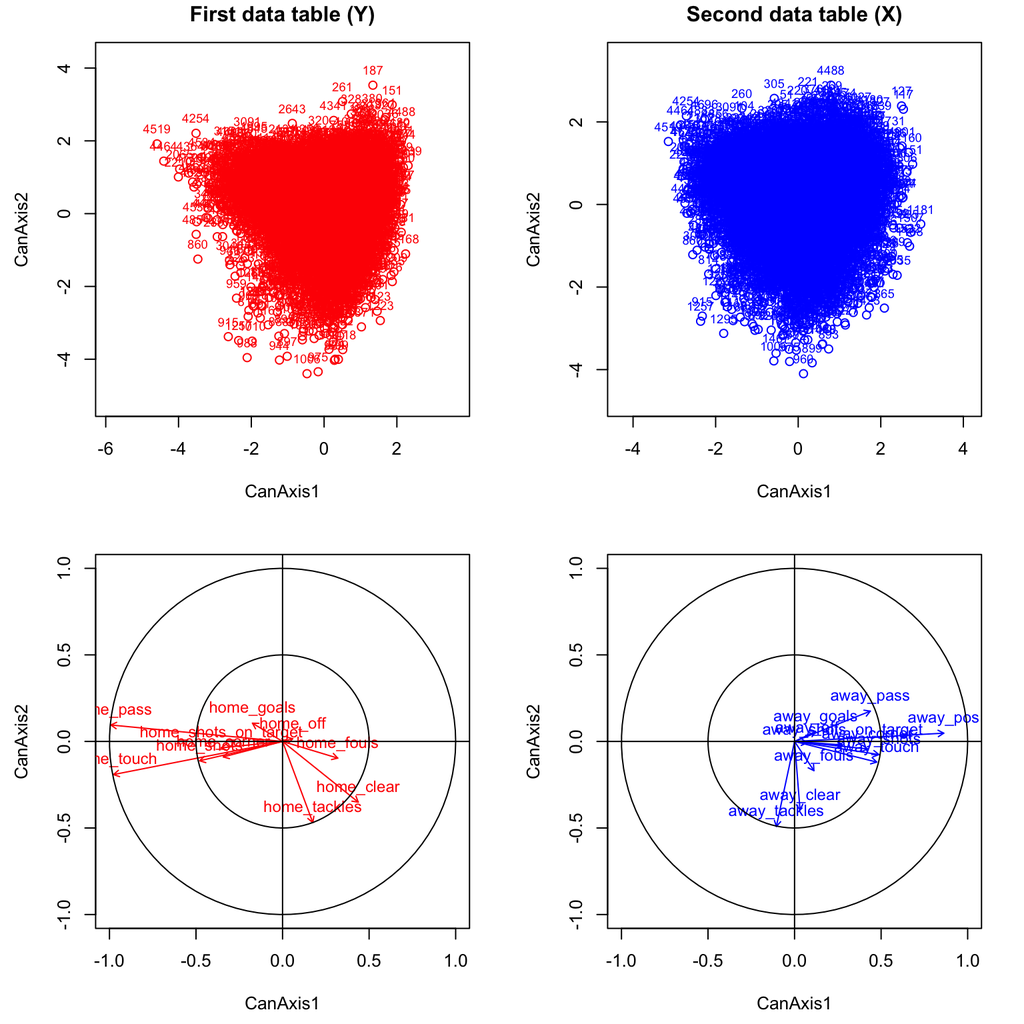

```r
biplot(EPL.cor)
```

The first row has the canonical variate scores for the first and second canonical variates, for both X and Y. We use these plots to see if the two datasets have similar outliers or clustering structures. The second row has arrows whose tips are the correlations of the original variables with the first two canonical variates. Because the variates are constrained to be orthogonal, the arrows cannot go outside the unit circle. Any arrow that reaches the unit circle represents a variable that can be perfectly reconsructed by the first two canonical variates. A short arrow indicates a variable that does not impact the first two canonical variates.

Now we will turn to PLS and PLSDA. In the version of pls we will study, one group of variables are considered the responses, the others the predictors. Here we will predict the home variables with the away variables. We need to choose the number of components to pay attention to. We can do this with cross validation. These root mean squared error (RMSE) plots show how both the error rate on the calibration set (the data used to fit the model, blue), and the set held out during cross validation (red). The model always fits the data used to build it slightly better; we see the blue line slightly lower than the red. However the red line is a better assessment of what will happen if we use the model for prediction with new data. After including five or six canonical variables, most of the models start to show diminishing returns. We need to manually set the number of components to be used. There are automatic criteria, but they don’t seem very stable in this package.

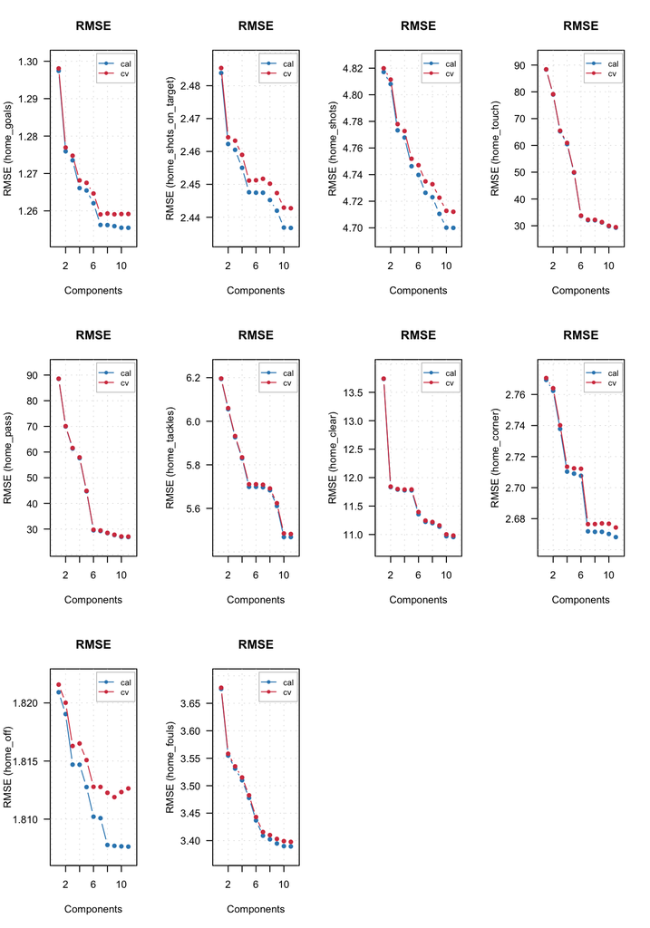

```r
pls(away, home, scale=TRUE, cv=10)->plsout
par(mfrow=c(3,4))
for(i in 1:10) plotRMSE(plsout,i)
selectCompNum(plsout,6)->plsout6
```

We can then assess how important each of our original variables is in predicting each of the responses. This is a combination of its effects on the 6 components. Note we have refitted to include only 6 components. The x axis is the index of our variable. We must specify the index of the response we are interested in (the default is the first response)

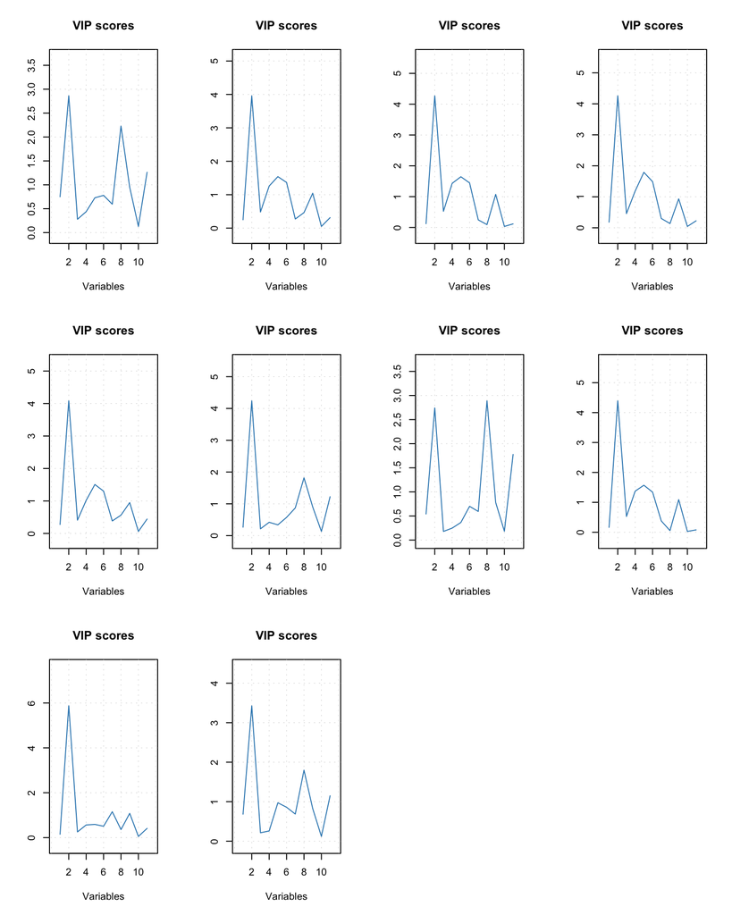

```r
par(mfrow=c(3,4))
for(i in 1:10) plotVIPScores(plsout6,i)
```

The second variable looks like the most important.

```r
names(away)[2]
```

```
## [1] "away_pos"
```

We can use plsda for predicting categorical outcomes. Here we will predict game outcome (but not using goals!) Note that unlike LDA, we can create more than number of groups -1 predictors. Here, the different “RMSEs” are for predicting the 0/1 variables for each category. If an observation has all zeros, or more than one 1, it is given no category.

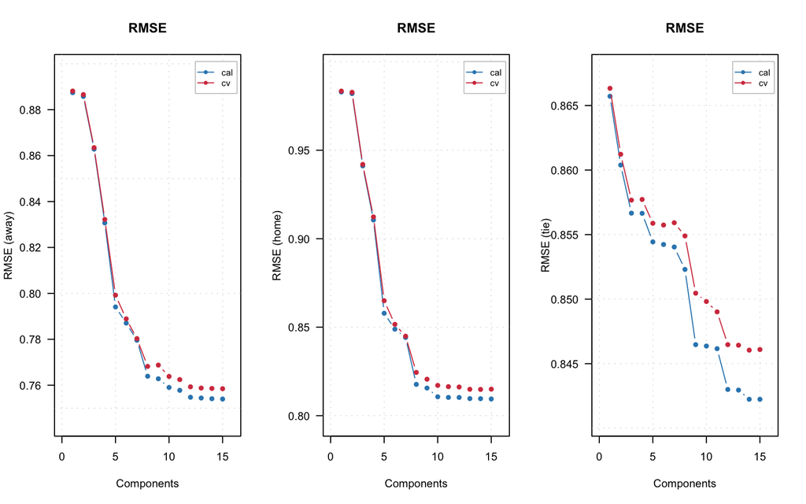

```r
home.wins<-EPL$winner
home.wins<-factor(home.wins, labels=c("tie", "home", "away"))
plsda(EPL[,5:28], home.wins, cv=10 )->wins.out

par(mfrow=c(1,3))
for(i in 1:3) plotRMSE(wins.out,i)
```

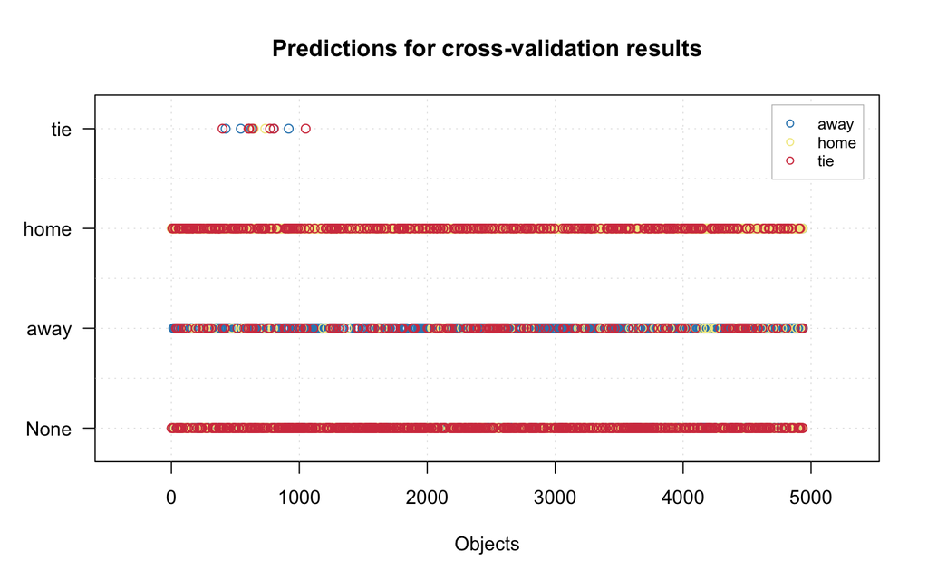

```r
selectCompNum(wins.out,8)->wins.out8
par(mfrow=c(1,1))
plotPredictions(wins.out8, pch=1)
```

Unfortunately there are too many points to see much from the default plot. We may also want to force a categorization into the “best” category, even if the prediction is not above 0. We will do this using the prediction in the cross validated results to get a picture of what performance might be like on future data.

```r
apply(wins.out8$cvres$y.pred[,8,],1, which.max)->prediction
prediction<-factor(prediction)
levels(prediction)<-c("pred:away", "pred:home", "pred:tie")
table(home.wins, prediction)
```

```
##          prediction
## home.wins pred:away pred:home pred:tie
##      tie        469       721       43
##      home       260      2001       28
##      away      1010       372       33
```